# About ABM

Published

November 20, 2025

# Background

## What is the aim of ABM at KTH?

The Annual Bibliometric Monitoring at KTH (shortened to ABM) contains statistics on publication output, citation impact, co-publishing, open access publishing and sustainable development goals.

The ABM, together with goals regarding publishing and citation, will be a part of the schools’ operational agreements and to be followed up in the school dialogues. It can be used as a basis for understanding how one’s own activities contribute to this goal.

## Which publications are included in ABM?

Publications registered in DiVA as affiliated to KTH and the examined unit (school, department or person) with publication years 2015 to 2024 are included in ABM. For the external data sources Web of Science, Scopus and Unpaywall, a connection to the DiVA publication needs to be found in the KTH bibliometric database Bibmet.

Only publications affiliated to KTH are included. This means that publications written by a researcher before she/he was employed at KTH, and that are not affiliated to KTH, will not be included in the statistics.

## At what organizational levels is it available?

The ABM is available at different levels - for KTH in total, schools, departments and individual researchers. Results for the schools and departments are open for all, but to see your individual ABM you will need to login.

## What data sources is it based on?

ABM is based on data in BIBMET (the bibliometric database at the KTH Library), which in turn collates data from other reference sources, including DiVA, Web Of Science, Scopus and Unpaywall. Statistics regarding citations, co‑publishing and open access are based on the subset of publications in DiVA that are registered in Web of Science (Citation impact, Journal impact and Co‑publishing tabs), Scopus (Scopus and SDG tabs) and Unpaywall (Open Access tab) respectively.

# Accessibility

We aim at providing content in an accessible fashion in compliance with [WCAG 2.1](https://www.w3.org/TR/WCAG21/), and are aware that there is room for improvement for some of the content.

If you require access to content not provided in a format that is accessible for you, please contact us at biblioteket@kth.se. Please find more information about accessibility at KTH at the [KTH Digital Accessibility web page](https://intra.kth.se/en/administration/kommunikation/webb/tillganglighet).

# Further information

## DAUF

The ABM is developed by [DAUF](https://bibliometrics.lib.kth.se), which is a collaboration between the [KTH Library](https://www.kth.se/en/biblioteket), [Research Support Office](https://intra.kth.se/en/styrning/kths-organisation/verksamhetsstod/forskningsstod-1.876021) and the [IT department](https://intra.kth.se/en/styrning/kths-organisation/verksamhetsstod/ita-1.879113) at KTH.

For further information of development of ABM and more, see the R pacakges bibliomatrix and kontarion.

## Contact

If you have further questions about the ABM at KTH please contact biblioteket@kth.se or submit a question using [this form](https://www.kth.se/biblioteket/anvanda-biblioteket/oppettider-kontakt/kontaktformular-1.863120).

## Additional links

- [Bibliometrics (KTH Library)](https://www.kth.se/biblioteket/publicera-analysera/analysera-forskning/bibliometri-1.1159501)
- Introduction to bibliometrics at KTH
- [Information about DiVA and the registration process - Handle publications in DiVA](https://www.kth.se/en/biblioteket/publicera-analysera/hantera-publikationer)
- [Statistics on Open Access publishing at KTH](https://bibliometrics.lib.kth.se/OA-rapport.html)
- Formal definitions of field normalized citation indicators at KTH

For further questions, contact the KTH Library at biblioteket@kth.se.

## Attribution for third-party data sources

### Redistribution rights for Web Of Science data

Certain data included in the Annual Bibliometric Monitoring report are derived from the © Science Citation Index Expended (SCIE), Social Sciences Citation Index (SSCI), Arts & Humanities Citation Index (AHCI), Conference Proceedings Citation Index - Sciences (CPCI-S) and Conference Proceedings Citation Index - Social Sciences & Humanities (CPCI -SSH) (2021) of Clarivate Analytics (US) LLC. All rights reserved. No part of these materials may be reproduced, stored in a retrieval system or transmitted in any form or by any means, including electronic, mechanical, photographic, magnetic or other means without the expressed permission of the KTH Library.

### Open Access data

Open Access status of publications is retrieved from [OpenAlex](https://openalex.org/).

### Scopus

Publication, citation, co-publication and SDG-data under the Scopus-tab is provided from [Scopus](https://www.scopus.com/) by [Elsevier](https://www.elsevier.com/). The data used in the ABM related to KTH is hosted in BIBMET.

## General denotation and description of bibliometric indicators at KTH

- **P full:** Full count of publications.
- **P frac:** Fractional count of publications. For fractional counts, the number of authors from the unit on each publication is divided by the total number of authors on the publikation, so if for example a department has 2 authors on a publication with 5 authors, the department’s fraction for that publication is 2/5 = 0.4. **P frac** is the sum of those fractions.
- **C full:** Full count of citations.
- **C frac:** Fractionalized count of citations.
- **C3 frac:** Fractionalized count of citations with a three year window. The indicator shows the number of citations received from publications published the same year and the two following years. Since older publications have had more time to get cited than new publications, time series of citations counts using an open window are not appropriate. By using a fixed citation window of three years comparisons over time can be made.
- **WoS coverage:** Share of publications covered by Web of Science.
- **Scopus coverage:** Share of publications covered by Scopus.
- **cf:** Mean field normalized citation rate. This indicator normalizes for the variation of citation pattern between subject fields. Each publication is compared to a reference group of publications, i.e. publications within the same Web of Science subject category, published the same year and of the same document type (article or review). This is done by dividing the number of citations of each publication with the average number of citations for the reference group of publications, which results in a normalized citation rate. The indicator value expresses the field normalized average citation rate of the unit’s publications. It follows from the definition of cf that the mean field normalized citation rate of all records in the Web of Science database is 1. A citation rate above one indicates that the set of publications is cited above world average, e.g. a citation rate of 1.2 indicates that the publications are cited 20 percent above world average.
- **Ptopx%:** The number or share of publications among the x percent most cited. The same reference group as for the field normalized citation rate is used for the indicator. Publications can partly belong to the x percent most cited publications if several publications have the same citation value as the percentile limit or if the publication has been classified into multiple fields with different percentile limits.
- **jcf:** Mean field normalized citation rate for journals and serials. This indicator shows the citation impact of the journals in which the unit has published. It is calculated as an average of the field normalized citation rate of the set of journals in which the analyzed unit has published. If the unit has published multiple articles in the same journal, the journal’s citation rate is counted one time for each article. This journal indicator is normalized for field differences by the same principles as the field normalized citation rate (cf). For a publication published in the year x, the value of the journal is based on the years x-1 to x-5.
- **JtopX%:** The number or share of publications that have been published in journals which are among the X percent most cited. The same reference group as for the journals’ field normalized citation rate (jcf) is used for the indicator. The journals in the topX% category publish X percent of the publications in the reference group. A journal can partly belong to the topX% percent if it stretches over the percentile limit or if it has been classified into multiple fields with different percentile limits.
- **International co-publishing:** The number of publications that has been co-published between two or more countries. The default presentation of this indicator is by full counts.
- **Swe. non-univ. co-publishing:** The number of publications that has been co-published between a university and Swedish non-university organizations. The default presentation of this indicator is by full counts.
- **Open Access publications:** Publications that are openly available to read, either from the publisher or from an open repository.
- **OA diamond:** Publications that are openly available to read from the publisher, with no article publicaiton cost.
- **OA gold:** Publications that are openly available to read from the publisher, in a fully OA journal, with an article publication cost.
- **OA hybrid:** Publications that are openly available to read from the publisher, in a journal that is not fully OA.
- **OA green:** Publications that are openly available to read from a repository, for example DiVA or arXiv.
- **SDG X:** Publications that relate to Sustainable Development Goal X.

# Guide to the Annual Bibliometric Monitoring at KTH

This guide gives an introduction to the Annual Bibliometric Monitoring (ABM) at KTH Royal Institute of Technology. The purpose of the guide is to help you navigate the presentation of results, to understand the bibliometric indicators used in the report, and to interpret the results.

## Background

The aim of the ABM is to assist monitoring, research evaluation and quality assurance at KTH, but also to provide KTH organizations and researchers with information related to their publications. The ABM was introduced in 2013 and was published annually in the same format since then. In 2019, a project aiming to redesign and develop the ABM was started. This resulted in the current solution, maintaining the same information as in previous years but in a more flexible framework with a presentation that is more dynamic, extendable and easier to maintain. That is the version of ABM described here.

The ABM results are available at different levels, for KTH in total, Schools, Departments and for individual researchers. The report currently has the same format and contents at all levels. Data is compiled in October - November each year and is presented for the last 10 full years.

Only publications registered in DiVA and affiliated with KTH are included in the results (i.e. publications that KTH researchers have published at other organizations are excluded). Affiliations to KTH are based on the actual author affiliation as written in the published paper. Indicators under Citation/Journal impact and Co-publishing tabs are based on Web of Science[^1], and indicators are therefore only presented for publications covered by Web of Science. Indicators under the Scopus and SDG tabs are only presented for publications covered by Scopus.

If a School or Department have changed name or the organizational structure has changed, publications affiliated to old organizational units have been assigned to the corresponding current unit when possible.

## Overview

The *Overview* tab includes key indicators displayed for the latest available time period[^2] and general information about ABM and publication activities at KTH.

Overviews at the KTH, school and department level are available to everyone, except for the button for publication list download which is only available for logged in KTH users.

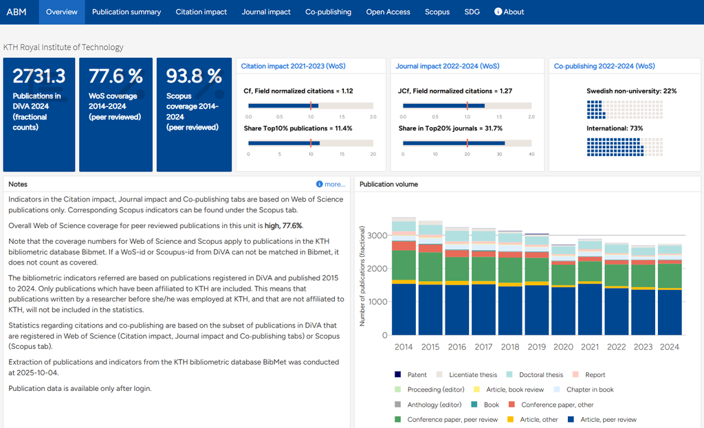

The individual view, only available to the researcher, also includes a link to edit publications in DiVA.

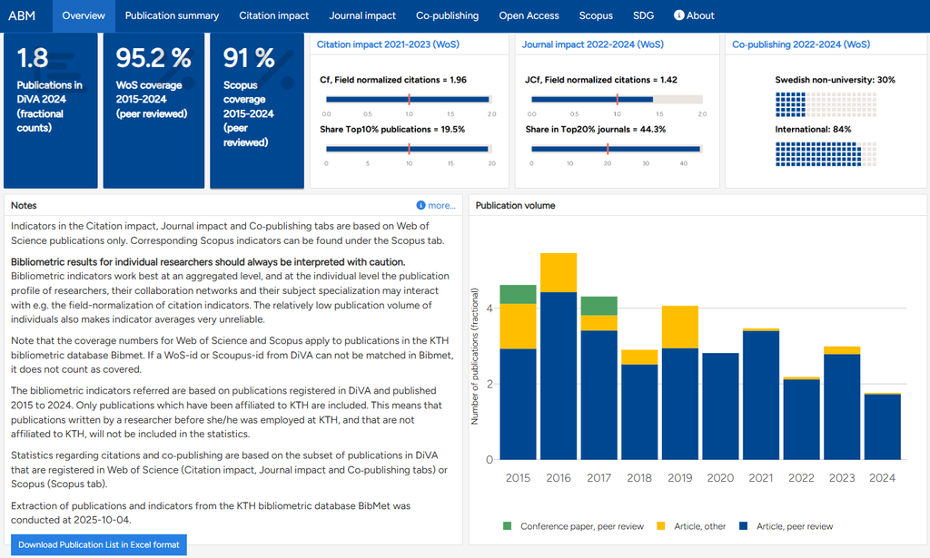

## Publications in DiVA

The *Publications in DiVA* tab shows the number of publications registered in DiVA for the researcher or organizational unit, by year and by publication type. Web of Science (WoS) and Scopus coverage are also shown for each publication type. The validity of bibliometric indicators is in general higher if the share of publications covered is high. Results based on publications with a smaller share covered should be treated with caution.

There is a tab for fractionalized counts and one for full counts. Both graphs are based on the fractionalized counts table.

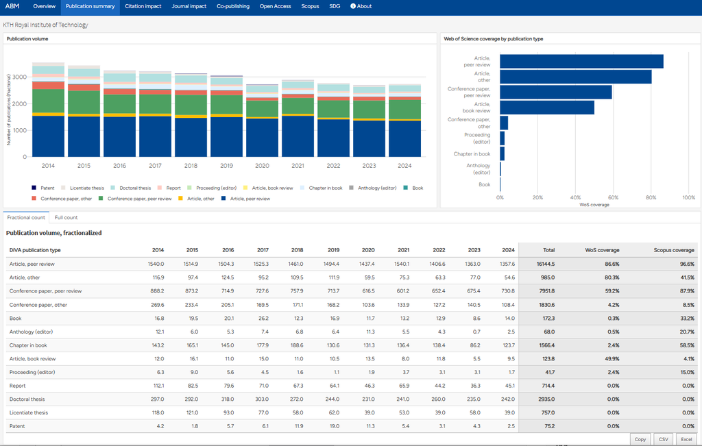

## Citation impact

The *Citation impact* tab shows citation impact for the researcher’s/unit’s publications. All indicators on this tab are based on fractionalized counts.

The first table in this view shows the total and average number of citations after three years, i.e. citations received in the publication year and the two directly following years, as well as the share of publications that were not cited in that time. This table is based on the Web of Science document types Article, Proceedings paper, Review, Letter and Editorial.

The second table is based on the Web of Science document types Article and Review, and shows Field Normalized Citations (Cf) and the share of publications belonging to the 10 percent most cited in its field.

The normalization is done so that the citation value for each publication is divided by the average number of citations received by publications from the same year, within the same Web of Science category (or categories) and of the same document type. For more detailed descriptions of the field normalized indicators used at KTH, see [Formal definitions](https://kth-library.github.io/abm/Formal_definitions_field_normalized_citation.pdf).

Mean-based citation indicators (such as Cf) can be strongly affected by a single publication (or a few) with a very high citation count relative to its field, while the Share Top 10% indicator is less sensitive to outliers. In that sense, Cf and Share Top 10% are complementary. Since field normalized indicators are unstable at low publication counts, the citation indicators are presented both as yearly values (dots) with a volume weighted three-year sliding mean superimposed in the graph to indicate the overall trend (solid line). Indicators based on a small number of publications should still be interpreted with caution.

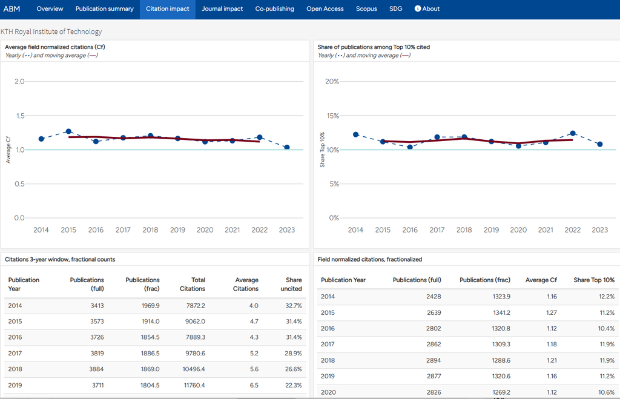

## Journal impact

The *Journal impact* tab shows the average citation impact of the journals where researcher’s/unit’s have published their publications. All numbers on this tab are based on fractionalized counts.

The table shows the average Journal Field Normalized Citations (JCf) and the share of publications in the 20 percent most cited journals in its Web of Science subject category/categories. This table is based on the publication types Article and Review.

The JCf and Share Top 20% indicators supplement each other the same way as the Cf and Share Top 10% indicators. By evaluating the impact of the journals rather than the publications themselves, these indicators supplement the picture of the publishing profile, and the journal indicators are often seen as a proxy of the quality of publication channels. JCf is also used as a part of the model for allocating KTH funding to the schools.

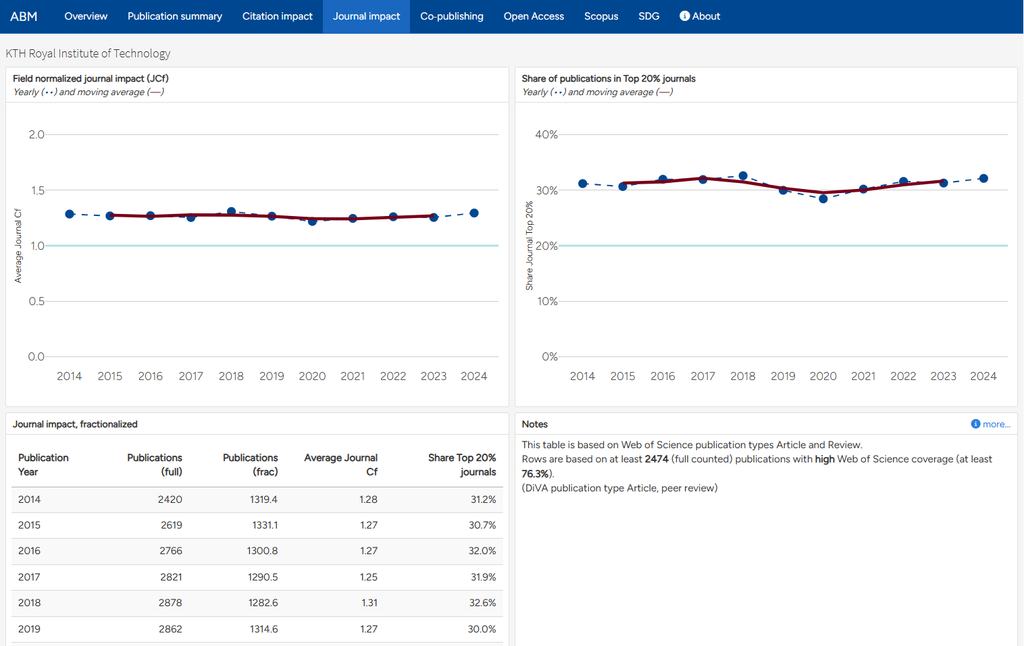

## Co-publishing

The *Co-publishing* tab shows the level of co-publication with universities and other organizations. All numbers on this tab are based on the Web of Science categories Article and Review and use full counts, i.e. a publication is counted as one even if there are many co-authors.

Here, a Swedish non-university co-publication means a publication with at least one address belonging to a Swedish organization outside academia while an International co-publication is a publication with at least two countries in the Web of Science addresses field.

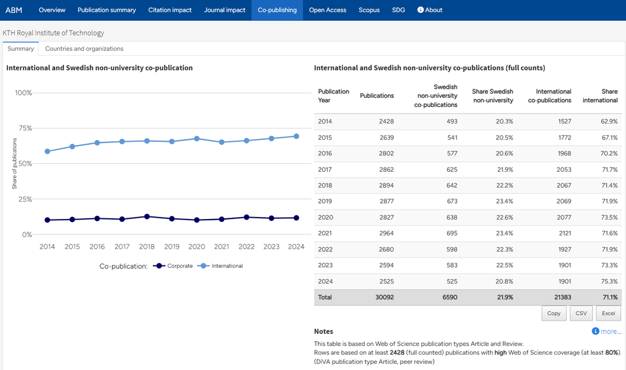

The sub-tab *Countries and organizations* contains list of the countries and organizations that the selected unit has co-published with, which can be searched and filtered. These tables are also summarized based on the number of co-authors on individual publications, to differentiate between smaller collaborations and collaborations based on large author groups. The number of rows shown can be selected under each table.

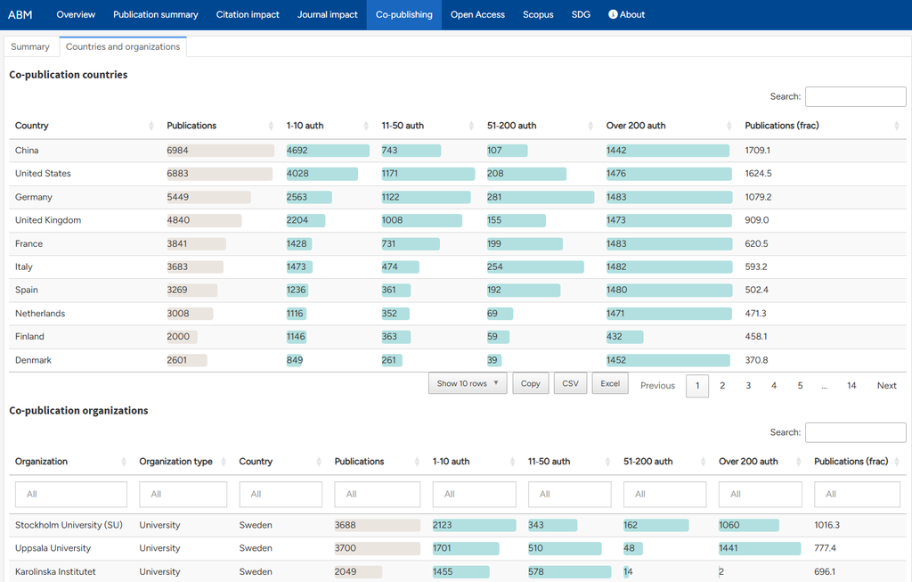

## Open Access

The *Open Access* tab shows the OA status of publications according to [OpenAlex](https://openalex.org). For a publication to be included, it needs to be marked as a peer reviewed publication in DiVA and have a Digital Object Identifier (DOI) that OpenAlex can recognice and determine an OA status for.

The statuses are presented as defined by OpenAlex with the exeption that we count bronze publications as closed. For further information, see [OpenAlex Support pages](https://help.openalex.org/hc/en-us/articles/24347035046295-Open-Access-OA).

Note that there is also a separate report only dealing with [Open Access at KTH](https://bibliometrics.lib.kth.se/OA-rapport.html). In addition to Open access-status across time that report also presents OA status for thesis, Article processing charges (APC) and OA-status for individual publication channels.

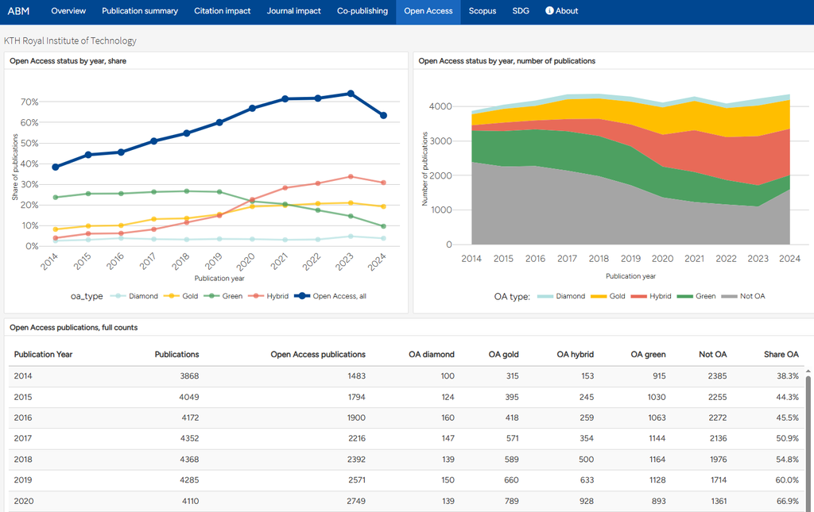

## Scopus

The *Scopus* tab presents bibliometric indicator data based on the Scopus database, as a complement to the indicators in the tabs *Citation impact*, *Journal impact* and *Co-publishing*. This *Scopus* tab has sub-tabs each containing data for one of these aspects. In *Citation impact*, the indicator for field-weighted normalized citations is called FWCI, which is similar to the Cf-indicator. The *Share Top 10%* is a direct parallell to the same indicator based on Web of Science data.

Field-normalization for the Scopus indicators are based on the same principles as the Web of Science-based indicators, but are based on the subject categories in the Scopus database and supplied directly by Scopus.

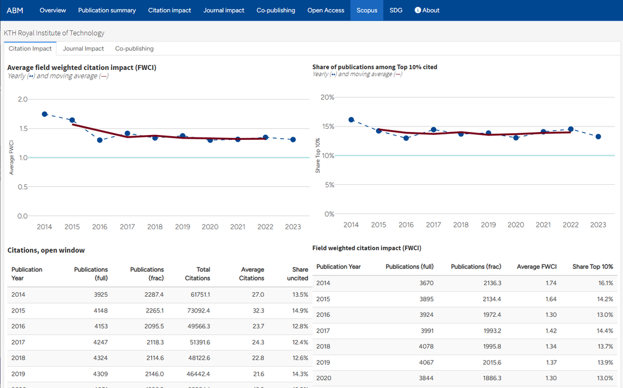

## SDG

The *SDG* tab provides an overview of how publications are mapped against the [UN sustainability goals (SDG)](https://sdgs.un.org/goals).

The mapping is provided from Scopus, and only publications present in the Scopus database are therefore included in the summary. Publications are mapped to SDGs based on search queries, using keywords found in titles, abstract and author keywords, and the full methodology is described by Scopus [here](https://elsevier.digitalcommonsdata.com/datasets/87txkw7khs/1). The same SDG-mapping is also used in e.g. the [*Times Higher Education Impact ranking* (THE Impact ranking)](https://www.timeshighereducation.com/impactrankings). Also note that individual publications can be mapped towards several SDGs.

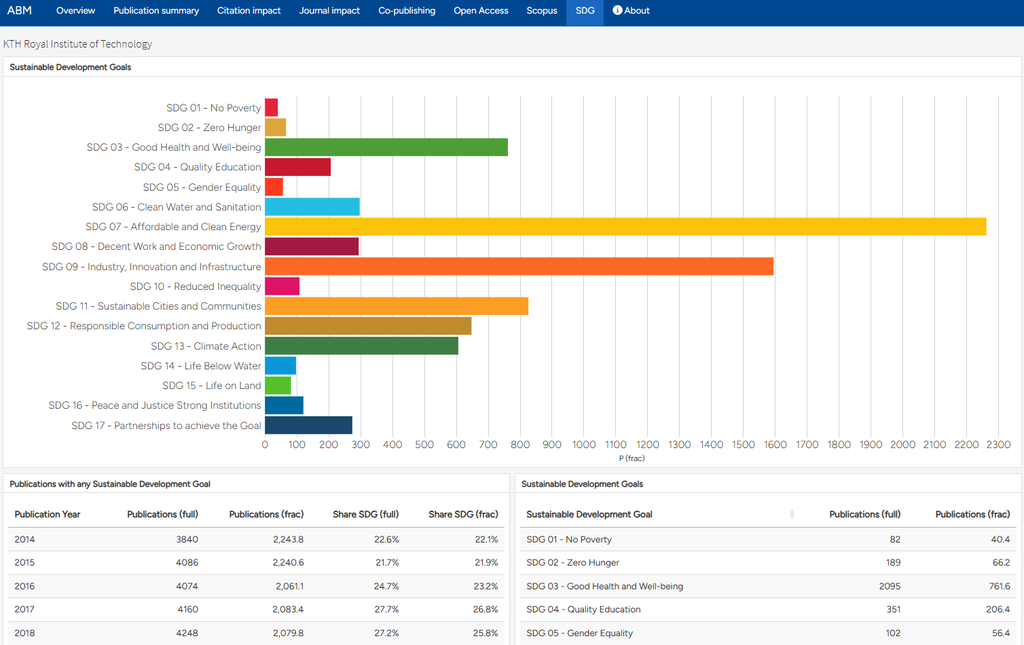

## Footnotes

[^1]: Included indices: Science Citation Index Expended (SCIE), Social Sciences Citation Index (SSCI), Arts &Humanities Citation Index (AHCI), Conference Proceedings Citation Index -Sciences (CPCI-S) and Conference Proceedings Citation Index -Social Sciences & Humanities (CPCI -SSH)
[^2]: Last year with a complete publication record in DiVA (usually year of last autumn – 1), with a non-zero count, for the Total publications number, the full period for WoS/Scopus coverage and last three-year period with an indicator for the other numbers.